# HW 7: Logistic Regression

Group A: Eli Polzer, Matt Futia, Mia McReynolds

05 March 2021

```r
# some pathnames; yours will be specific to your CPU !!
  path.root <- "~/University of Vermont/Classes/sdhmR/sdhmR-V2021.1"

# below is the recommended class root dir
  #path.root <- "~/sdhmR-V2021.1"  # typical class root dir
  path.mod2 <- paste(path.root, "/data/module02", sep = "")
   path.mod5 <- paste(path.root, "/data/module05.01-LR", sep = "")
  path.figs <- paste(path.root, "/powerpoints/figures", sep = "")
  path.gis <- paste(path.root, "/data/gis_layers", sep = "")

# some libraries
  library(tidyverse)
   library(PresenceAbsence)  # fxns: optimal.thresholds, presence.absence.accuracy,
                            #       auc.roc.plot
  library(DAAG)             # fxns: CVbinary
  library(data.table)
  library(raster)
  library(sf)
```

## Question #1

- Import and explore data
  - **NOTE**: intent is not to reduce number of variables; that was completed in exercise #5. Rather, calculate simple descriptive statistics (mean, sd, n) and boxplots

```r
# load range-wide training data
load("~/University of Vermont/Classes/sdhmR/sdhmR-V2021.1/data/module02/tr_RANG.Rdata")

str(tr_RANG)
```

```
## 'data.frame':    5997 obs. of  11 variables:
##  $ FNETID    : num  9270 13732 22606 24072 40340 ...
##  $ RANG106   : num  0 0 0 0 0 0 0 0 0 0 ...
##  $ tr.wgs_x  : num  -111 -111 -111 -111 -111 ...
##  $ tr.wgs_y  : num  42.1 42.1 42 42 41.9 ...
##  $ etpt_5    : num  88 85 88 85 88 79 85 75 88 87 ...
##  $ mind_yr_av: num  -1105 -1008 -1141 -1025 -1153 ...
##  $ prad_sw_di: num  12163 12285 12079 12120 12181 ...
##  $ prec_w_hal: num  25.7 27.2 19.8 27.2 18.2 ...
##  $ rough_1k  : num  1.66 16.45 11.39 12.19 1.19 ...
##  $ tmax_s_hal: num  224 201 218 201 221 ...
##  $ topos     : num  -89.9 16.8 -46.7 22.7 -30.8 ...
```

```r
#pivot for ggplotting
tr_RANG_long <- tr_RANG %>%
  pivot_longer(etpt_5:topos, names_to = "Variable", values_to = "Value")

head(tr_RANG_long, 3)
```

```
## # A tibble: 3 x 6
##   FNETID RANG106 tr.wgs_x tr.wgs_y Variable    Value
##    <dbl>   <dbl>    <dbl>    <dbl> <chr>       <dbl>
## 1   9270       0    -111.     42.1 etpt_5        88
## 2   9270       0    -111.     42.1 mind_yr_av -1105.
## 3   9270       0    -111.     42.1 prad_sw_di 12163.
```

```r
#summarise data
tr_RANG_long %>% group_by(Variable) %>%
  summarise(n = n(),
            mean = mean(Value),
            sd = sd(Value),
            min = min(Value),
            max = max(Value))
```

```
## # A tibble: 7 x 6
##   Variable       n     mean     sd      min    max
##   <chr>      <int>    <dbl>  <dbl>    <dbl>  <dbl>
## 1 etpt_5      5997    91.6    7.30     0       99
## 2 mind_yr_av  5997 -1400.   323.   -2065.     153.
## 3 prad_sw_di  5997 10929.   684.    8070.   13026.
## 4 prec_w_hal  5997    26.1   13.1      6.33   130.
## 5 rough_1k    5997    17.3   15.7      0      130.
## 6 tmax_s_hal  5997   249.    38.5     87.8    368.
## 7 topos       5997     1.55  48.7   -209.     334
```

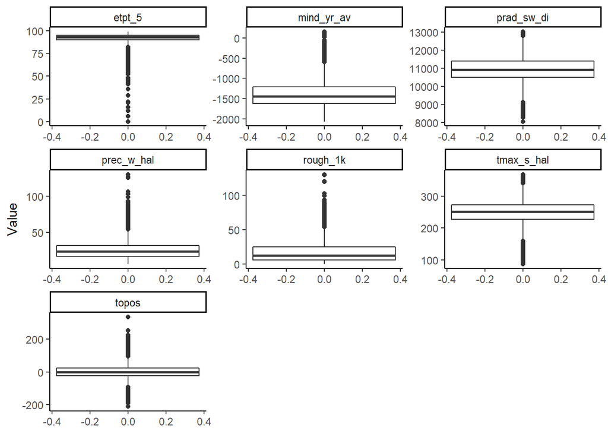

```r
#boxplot
ggplot(tr_RANG_long, aes(y=Value)) +
  geom_boxplot() +
  facet_wrap(~Variable, scales="free") +
  theme_classic()
```

## Question #2

- Construct full- and reduced-variable logistic GLM’s
- Determine an estimate of model fit, based on deviance.

```r
######## START MODEL #1 => FULL MODEL, ALL VARS INCLUDED
  mod1.LR.RANG <- glm(as.factor(RANG106) ~ etpt_5 + mind_yr_av + prad_sw_di + prec_w_hal + rough_1k + tmax_s_hal + topos, family = binomial, data = tr_RANG)

# model 1 summary
  summary(mod1.LR.RANG) # full model summary stats
```

```
##
## Call:
## glm(formula = as.factor(RANG106) ~ etpt_5 + mind_yr_av + prad_sw_di +
##     prec_w_hal + rough_1k + tmax_s_hal + topos, family = binomial,
##     data = tr_RANG)
##
## Deviance Residuals:
##     Min       1Q   Median       3Q      Max
## -2.2164  -0.8752  -0.5815   1.1258   2.4109
##
## Coefficients:
##               Estimate Std. Error z value Pr(>|z|)
## (Intercept) -5.102e+01  2.683e+00 -19.018  < 2e-16 ***
## etpt_5       5.430e-01  3.000e-02  18.101  < 2e-16 ***
## mind_yr_av  -3.114e-03  5.160e-04  -6.034  1.6e-09 ***
## prad_sw_di   1.151e-03  7.762e-05  14.831  < 2e-16 ***
## prec_w_hal   3.897e-02  4.122e-03   9.454  < 2e-16 ***
## rough_1k     2.406e-02  2.127e-03  11.312  < 2e-16 ***
## tmax_s_hal  -7.291e-02  3.743e-03 -19.477  < 2e-16 ***
## topos        1.181e-03  6.361e-04   1.856   0.0634 .
## ---
## Signif. codes:  0 '***' 0.001 '**' 0.01 '*' 0.05 '.' 0.1 ' ' 1
##
## (Dispersion parameter for binomial family taken to be 1)
##
##     Null deviance: 7634.4  on 5996  degrees of freedom
## Residual deviance: 6660.6  on 5989  degrees of freedom
## AIC: 6676.6
##
## Number of Fisher Scoring iterations: 6
```

```r
# model 1 fit
  mod1.fit <- 100 * (1 - mod1.LR.RANG$deviance/mod1.LR.RANG$null.deviance)
      # extract values from above
  mod1.fit  # examine fit
```

```
## [1] 12.75532
```

```r
# model 1 prediction
mod1.pred <- predict(mod1.LR.RANG, type = "response") # model prediction
head(mod1.pred) # examine prediction - should be same length as input dataframe
```

```
##          1          2          3          4          5          6
## 0.24030565 0.32340342 0.33947960 0.27477464 0.26451635 0.08475189
```

```r
######## START MODEL #2 => REDUCED VARIABLE MODEL
# build parsimonious model w/var reduction techniques: mod2.LR
#   variable reduction: backwards
  mod2.LR.RANG <- step(mod1.LR.RANG, trace = F) # backwards stepwise variable reduction
  summary(mod2.LR.RANG) # reduced model
```

```
##
## Call:
## glm(formula = as.factor(RANG106) ~ etpt_5 + mind_yr_av + prad_sw_di +
##     prec_w_hal + rough_1k + tmax_s_hal + topos, family = binomial,
##     data = tr_RANG)
##
## Deviance Residuals:
##     Min       1Q   Median       3Q      Max
## -2.2164  -0.8752  -0.5815   1.1258   2.4109
##
## Coefficients:
##               Estimate Std. Error z value Pr(>|z|)
## (Intercept) -5.102e+01  2.683e+00 -19.018  < 2e-16 ***
## etpt_5       5.430e-01  3.000e-02  18.101  < 2e-16 ***
## mind_yr_av  -3.114e-03  5.160e-04  -6.034  1.6e-09 ***
## prad_sw_di   1.151e-03  7.762e-05  14.831  < 2e-16 ***
## prec_w_hal   3.897e-02  4.122e-03   9.454  < 2e-16 ***
## rough_1k     2.406e-02  2.127e-03  11.312  < 2e-16 ***
## tmax_s_hal  -7.291e-02  3.743e-03 -19.477  < 2e-16 ***
## topos        1.181e-03  6.361e-04   1.856   0.0634 .
## ---
## Signif. codes:  0 '***' 0.001 '**' 0.01 '*' 0.05 '.' 0.1 ' ' 1
##
## (Dispersion parameter for binomial family taken to be 1)
##
##     Null deviance: 7634.4  on 5996  degrees of freedom
## Residual deviance: 6660.6  on 5989  degrees of freedom
## AIC: 6676.6
##
## Number of Fisher Scoring iterations: 6
```

```r
# model 1 v. model 2 fit: both pretty bad
  100 * (1 - mod1.LR.RANG$deviance/mod1.LR.RANG$null.deviance)  # fit model 1
```

```
## [1] 12.75532
```

```r
  100 * (1 - mod2.LR.RANG$deviance/mod2.LR.RANG$null.deviance)  # fit model 2
```

```
## [1] 12.75532
```

Both of these models have the same formula, so their fit is the same. Not very good overall.

```r
# model 1 vs. 2 predictions
  mod2.pred <- predict(mod2.LR.RANG, type = "response") # model prediction
  head(mod2.pred)
```

```
##          1          2          3          4          5          6
## 0.24030565 0.32340342 0.33947960 0.27477464 0.26451635 0.08475189
```

```r
  head(mod1.pred)
```

```
##          1          2          3          4          5          6
## 0.24030565 0.32340342 0.33947960 0.27477464 0.26451635 0.08475189
```

## Question #3

- Calculate accuracy metrics (full set as in Module 3.2 and 3.3, Analytical Intermission) using:
  - Resubstitution approaches, and
  - A 10-fold cross–validation approach

### Resubstitution approaches

```r
######## START RESUBSTITUTION ACCURACY CALCULATIONS, MODEL=LOGISTIC GLM
# requires pkg PresenceAbsence
#   build testing dataframe using mod2 predictions
  modl <- "mod.LR.RANG" # add var to keep track of model
  dat2 <- cbind(modl, tr_RANG[2], mod2.pred) # build dataframe w/mod2 predictions
  head(dat2, 2) # examine prediction dataframe
```

```
##          modl RANG106 mod2.pred
## 1 mod.LR.RANG       0 0.2403057
## 2 mod.LR.RANG       0 0.3234034
```

```r
# determine best threshold using PresenceAbsence package Sec7.1
  mod.cut <- optimal.thresholds(dat2, opt.methods = c("Default")) # default threshold=0.5
  mod.cut # examine threshold=DEFAULT of 0.5
```

```
##    Method mod2.pred
## 1 Default       0.5
```

```r
# generate confusion matrix
  mod2.cfmat <- table(dat2[[2]], factor(as.numeric(dat2$mod2.pred >= mod.cut$mod2.pred)))
  mod2.cfmat # examine
```

```
##
##        0    1
##   0 3476  522
##   1 1364  635
```

```r
# calculate model accuracies with standard deviation=F
  mod2.acc <- presence.absence.accuracy(dat2, threshold = mod.cut$mod2.pred, st.dev = F)
  tss <- mod2.acc$sensitivity + mod2.acc$specificity - 1 # code TSS metric
  mod2.acc <- cbind(mod2.acc[1:7], tss) # bind all metrics
  mod2.acc[c(1, 4:5, 7:8)] # examine accuracies
```

```
##       model sensitivity specificity      AUC       tss
## 1 mod2.pred   0.3176588   0.8694347 0.737092 0.1870935
```

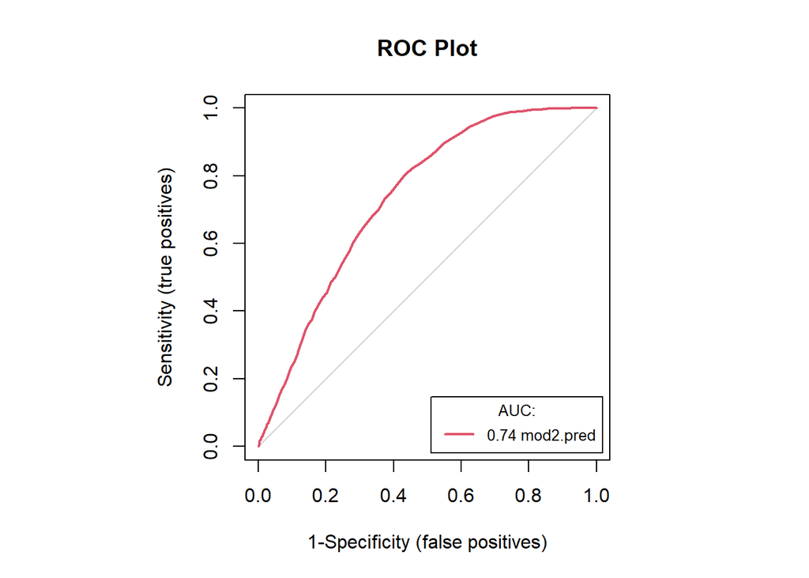

```r
# plotting AUC
  auc.roc.plot(dat2, color = T) # basic AUC plot; pkg PresenceAbsence
```

### 10-fold cross validation approach

```r
# perform 10-fold cross-validation
  set.seed(1234) # set and save seed if desire replicability of samples
  #library(DAAG) # load pkg for crossval
  glm.cv10 <- CVbinary(mod1.LR.RANG, nfolds = 10, print.details = F) # crossval w/10 folds
  head(glm.cv10$cvhat) # examine
```

```
## [1] 0.24200977 0.32470052 0.34491032 0.27984165 0.26984002 0.08525268
```

### Compare both

```r
# examine resubstitution and cross-validation estimates
  glm.pred <- mod2.pred # examine resub prediction
head(glm.pred)
```

```
##          1          2          3          4          5          6
## 0.24030565 0.32340342 0.33947960 0.27477464 0.26451635 0.08475189
```

```r
head(glm.cv10$cvhat) # examine xval prediction
```

```
## [1] 0.24200977 0.32470052 0.34491032 0.27984165 0.26984002 0.08525268
```

```r
  glm.cvpred <- glm.cv10$cvhat # assign new name to crossval estimates
  spp <- "spp106"
  dat2 <- cbind(spp, tr_RANG[2], glm.pred, glm.cvpred) # build dataframe: true data plus the 2 validations
  head(dat2, 2) # examine; NOTE will differ each run unless seed is saved
```

```
##      spp RANG106  glm.pred glm.cvpred
## 1 spp106       0 0.2403057  0.2420098
## 2 spp106       0 0.3234034  0.3247005
```

```r
# estimate both resub and crossval accuracies
#  create 3-column dataframes for PresenceAbsence
  dat3 <- dat2[, c(1:3)] # includes column glm.pred
  dat4 <- dat2[, c(1:2, 4)] # includes column glm.cvpred
```

```r
# calculate model accuracies; resubstitution
  mod.cut <- optimal.thresholds(dat3, opt.methods = c("ObsPrev")) # threshold=PREVALENCE
  mod1.acc <- presence.absence.accuracy(dat3,threshold = mod.cut$glm.pred)
  tss <- mod1.acc$sensitivity + mod1.acc$specificity - 1 # code TSS metric
  dat3.acc <- cbind(mod1.acc[1:7], tss) # bind all metrics
  head(dat3.acc) # examine
```

```
##      model threshold       PCC sensitivity specificity     Kappa      AUC
## 1 glm.pred 0.3333333 0.6664999   0.6948474   0.6523262 0.3163172 0.737092
##         tss
## 1 0.3471736
```

```r
# calculate model accuracies; cross-validation
  mod.cut <- optimal.thresholds(dat4, opt.methods = c("ObsPrev")) # threshold=PREVALENCE
  mod1.acc <- presence.absence.accuracy(dat4, threshold = mod.cut$glm.cvpred)
  tss <- mod1.acc$sensitivity + mod1.acc$specificity - 1 # code TSS metric
  dat4.acc <- cbind(mod1.acc[1:7], tss) # bind all metrics
  head(dat4.acc) # examine
```

```
##        model threshold       PCC sensitivity specificity     Kappa       AUC
## 1 glm.cvpred 0.3333333 0.6651659   0.6933467   0.6510755 0.3137389 0.7354963
##         tss
## 1 0.3444222
```

```r
# bind all accuracies into single dataframe
  all.acc <- rbind(dat3.acc, dat4.acc) # bind all metrics
  all.acc # examine - usually just report the cvpred (cross-validated).
```

```
##        model threshold       PCC sensitivity specificity     Kappa       AUC
## 1   glm.pred 0.3333333 0.6664999   0.6948474   0.6523262 0.3163172 0.7370920
## 2 glm.cvpred 0.3333333 0.6651659   0.6933467   0.6510755 0.3137389 0.7354963
##         tss
## 1 0.3471736
## 2 0.3444222
```

Very similar results in resubstitution and cross-validation approaches, so this model may be able to handle new data decently.

## Question #4

- Build 2 prediction maps:
  - A raw probability estimate for each cell in the modelling domain; and
  - A classified map based on the selected threshold from Question #3

```r
#load raster stack - pied.topoDOM
load("~/University of Vermont/Classes/sdhmR/sdhmR-V2021.1/data/module02/rangeDOM.RData")

# predict for LR & GAM
#  S=raster stack; M=RF model; N.img=save an .img file
#  accept the rest as R catechism specific to LR & GAM
rang.probLR <- predict(rangeDOM,mod1.LR.RANG,filename="rang.probLR.img",type="response",fun=predict,index=2, overwrite=TRUE)
rang.probLR
```

```
## class      : RasterLayer
## dimensions : 1518, 1478, 2243604  (nrow, ncol, ncell)
## resolution : 0.008333333, 0.008333333  (x, y)
## extent     : -114.6167, -102.3, 29.49167, 42.14167  (xmin, xmax, ymin, ymax)
## crs        : +proj=longlat +ellps=WGS84 +no_defs
## source     : C:/Users/miamc/Documents/sdhmR-V2021.1EXP/exercises/rang.probLR.img
## names      : rang.probLR
## values     : 2.220446e-16, 0.9833609  (min, max)
```

```r
# classification raster; bit more complicated
#   first determine classification threshold -- did this above.
  mod.cut
```

```
##    Method glm.cvpred
## 1 ObsPrev  0.3333333
```

```r
rang.clasLR <- reclassify(rang.probLR, filename = "range.clas.LR.img",
   (c(0, mod.cut[[2]], 0, mod.cut[[2]], 1, 1)), overwrite=TRUE)
```

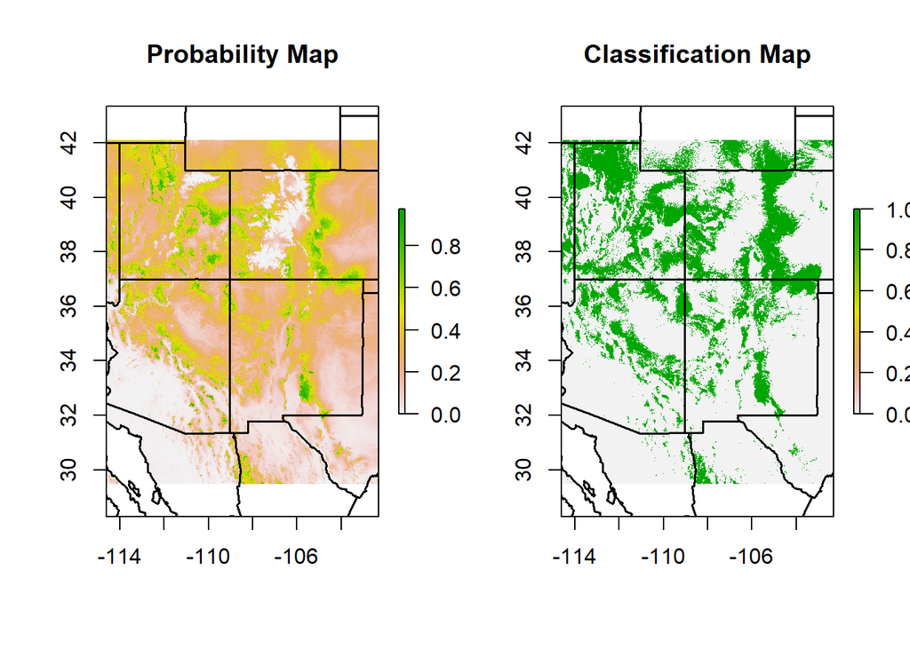

```r
######## START PROBABILITY & CLASSIFICATION PLOTS
# boundaries for pretty maps (see Mod 2.5)
  setwd(path.gis)
  states <- st_read(dsn = ".", layer = "na_states_wgs") # import shapefile
# giggle maps
  par(mfrow = c(1, 2))
  plot(rang.probLR, legend = T, axes = T, main = "Probability Map") # plot probability map
  plot(st_geometry(states), add = T, lwd = 1.5) # add state boundaries
  plot(rang.clasLR, legend = T, axes = T, main = "Classification Map") # plot classification map
  plot(st_geometry(states), add = T, lwd = 1.5) # add state boundaries
```

```r
  par(mfrow = c(1, 1))

  LRmaps_EX07 <- recordPlot()
```

## Question #5

- Save your data as R objects:
  - Accuracy metrics as a dataframe;
  - Classification threshold as a stand–alone scalar
  - Both prediction maps as **`.img`** format
- Save these R objects in a **`.RData`** file

These data will be used again in Module 10, Ensemble Models.

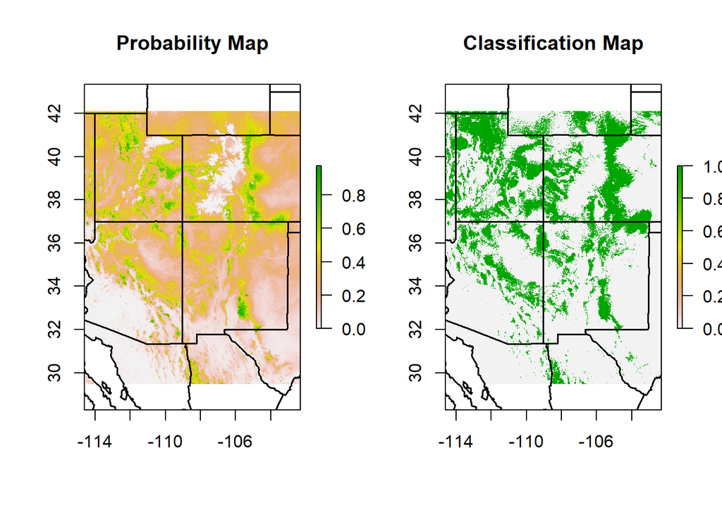

```r
setwd(path.mod5)
# Accuracy metrics as a dataframe
all.acc_EX07 <- all.acc

# Classification threshold as a stand--alone scalar
mod.cut_EX07 <- mod.cut[[2]]

#plot - also saved this manually
LRmaps_EX07
```

```r
save(all.acc_EX07, mod.cut_EX07, LRmaps_EX07, file = "range.LR_EX07.RData")
```